```r
setwd("~/Documents/R/Networks")
library(rtweet)
library(rtweet)
library(readr)
library(tidyverse)
load("~/Documents/R/Networks/sen_friends.RData")
load("~/Documents/R/Networks/rep_friends.RData")
legs <- read_csv("legislators-current.csv")
legs <- legs %>% filter(type=='sen'|type=='rep') %>% select(twitter,party,govtrack_id,type)
legs <- na.omit(legs)
sens <- legs %>%filter(type == 'sen') %>% select(twitter,party,govtrack_id)
reps <- legs %>% filter(type=='rep') %>% select(twitter,party,govtrack_id)
```

Make dataframe of followers/followed Each row is a uni-directional follow from “follower” to “followed”

```r
senrep <- rbind(sens,reps)
senrep_friends <-rbind(sen_friends,rep_friends)
senrep_friends
```

```
## # A tibble: 55,688 x 2
##    follower        followed
##    <chr>           <chr>
##  1 SenSherrodBrown RepAGonzalez
##  2 SenSherrodBrown RepBalderson
##  3 SenSherrodBrown WarrenDavidson
##  4 SenSherrodBrown SenBillCassidy
##  5 SenSherrodBrown SenRickScott
##  6 SenSherrodBrown SenatorBraun
##  7 SenSherrodBrown SenHawleyPress
##  8 SenSherrodBrown SenMcSallyAZ
##  9 SenSherrodBrown MarshaBlackburn
## 10 SenSherrodBrown SenKevinCramer
## # ... with 55,678 more rows
```

Break into Republicans and Democrats (slightly more of the former than the latter)

```r
republicans <- senrep$twitter[sens$party=='Republican']
length(republicans)
```

```
## [1] 278
```

```r
democrats <- senrep$twitter[sens$party=='Democrat']
length(democrats)
```

```
## [1] 243
```

Make two graphs: one of only Democrats, one of only Republicans

```r
r_follows <- senrep_friends %>% filter(follower %in% republicans & followed %in% republicans)
d_follows <- senrep_friends %>% filter(follower %in% democrats & followed %in% democrats)

library(igraph)
g <- graph_from_data_frame(senrep_friends, directed=TRUE)
d <- graph_from_data_frame(d_follows, directed=TRUE,vertices=democrats)
r <- graph_from_data_frame(r_follows, directed=TRUE,vertices=republicans)
```

Examine the edge density of Republican, Democrat, and full network

```r
edge_density(g)
```

```
## [1] 0.1699069
```

```r
edge_density(d)
```

```
## [1] 0.1862225
```

```r
edge_density(r)
```

```
## [1] 0.1788562
```

The Democrat network is more dense than the Republican, which are both more dense than the overall network

Similarly, transitivity is lower for the overall network, highest for Republican network

```r
transitivity(g)
```

```
## [1] 0.5383434
```

```r
transitivity(d)
```

```
## [1] 0.5744101
```

```r
transitivity(r)
```

```
## [1] 0.5917161
```

Analyze which users are followed by the highest number of other legislators

```r
in_degree <- degree(g,mode='in')
sort(in_degree,decreasing=TRUE)[1:10 ] #who is followed by the most people
```

```
##   SpeakerPelosi       GOPLeader     LeaderHoyer   SenatorSinema
##             228             220             206             197
##    SteveScalise   cathymcmorris      JohnCornyn      SenSchumer
##             186             180             177             177
## SenatorTimScott   senrobportman
##             173             172
```

```r
r_follows_d <- senrep_friends %>% filter(follower %in% republicans & followed %in% democrats)
d_follows_r <- senrep_friends %>% filter(follower %in% democrats & followed %in% republicans)
nrow(r_follows_d)/length(republicans) #average number of out-of-party follows for republicans
```

```
## [1] 42.08273
```

```r
nrow(d_follows_r)/length(democrats) #average number of out-of-party follows for democrats
```

```
## [1] 47.36214
```

```r
nrow(r_follows)/length(republicans) #average number of within-party follows for republicans
```

```
## [1] 49.54317
```

```r
nrow(d_follows)/length(democrats) #average number of within-party follows for democrats
```

```
## [1] 45.06584
```

Democrats have more out-of-party follows than Republicans, and Republicans have more within-party follows than Democrats

Load tweets about Impeachment

```r
load("~/Documents/R/Networks/total_tweets_3.RData")
impeach <- str_detect(tweets$text, regex('impeach',ignore_case=TRUE))
impeach_tweets_full <- tweets %>% filter(impeach)
impeach_tweets <- impeach_tweets_full %>% select(status_id,screen_name,text)
```

Make dataframe of legislators and their tweets on impeachment

```r
load("~/Documents/R/Networks/legislators.RData")

names(impeach_tweets) <- c("status_id","twitter","text")
impeach_tweets$twitter<-tolower(impeach_tweets$twitter)
impeachment<-impeach_tweets %>% left_join(legislators,by='twitter')
impeachment$status_id_binary <-ifelse(is.na(impeachment$status_id),0,1)
impeachment <- impeachment %>% group_by(twitter) %>% mutate(numtweets = sum(status_id_binary)) %>% dplyr::select(twitter,party,numtweets)
impeachment <- distinct(impeachment)
num_tweets <- impeachment %>% dplyr::select(twitter,numtweets)
legislators <- legislators %>% left_join(num_tweets,by='twitter')
legislators$numtweets<-ifelse(is.na(legislators$numtweets),0,legislators$numtweets)

tweet_count = impeach_tweets_full %>% dplyr::select(created_at,screen_name)
tweet_count$screen_name<-tolower(tweet_count$screen_name)
tweet_count$created_at<-as.Date(tweet_count$created_at)
names(tweet_count) <- c("created_at","twitter")
tweet_dates<-aggregate(tweet_count$created_at, list(tweet_count$twitter), paste, collapse="/")
names(tweet_dates)<-c("twitter","dates")

legislators <- legislators %>% left_join(tweet_dates,by='twitter')
legislators
```

```
## # A tibble: 532 x 10
##    twitter party govtrack_id type  terms followed_by follows gender
##    <chr>   <fct>       <int> <chr> <int>       <dbl>   <dbl> <fct>
##  1 senshe… Demo…      400050 sen      10         144     113 M
##  2 senato… Demo…      300018 sen       5         122     116 F
##  3 senato… Demo…      400064 sen      13         131     131 M
##  4 senato… Demo…      300019 sen       9         119      94 M
##  5 senbob… Demo…      412246 sen       3         134     104 M
##  6 senfei… Demo…      300043 sen       6         161      68 F
##  7 senamy… Demo…      412242 sen       3          52      61 F
##  8 senato… Demo…      400272 sen      11         132      88 M
##  9 sensan… Inde…      400357 sen      11         153      71 M
## 10 sensta… Demo…      300093 sen       6         115      62 F
## # ... with 522 more rows, and 2 more variables: numtweets <dbl>,
## #   dates <chr>
```

Make network about impeachment discussion, and interactions with other legislators on twitter

```r
df <- impeach_tweets_full
# all mentions, as string
mention_list <- vector("list", nrow(impeach_tweets_full))
for(i in 1:nrow(impeach_tweets_full)){
  mentions <- impeach_tweets_full$mentions_screen_name[i][[1]]
  mentions <- paste(mentions,collapse=',')[[1]]
  mention_list[[i]]<-ifelse(mentions=="NA",NA,mentions)
}
df$mentions <- mention_list
df <- transform(df, mentions = as.character(mentions))
df <- df %>% dplyr::select(screen_name,reply_to_screen_name,quoted_screen_name,retweet_screen_name,mentions,text,status_id,created_at)
# all interactions as string
df <- unite(df,interaction_name,2:5,sep=",",remove=FALSE)
# all interactions, separate rows, edges only when interacting with other legislators
df <- separate_rows(df,interaction_name) %>% filter(tolower(interaction_name) %in% legislators$twitter)
df <- unique(df)
# remove self edges
df <- filter(df,interaction_name!=screen_name)

# tweet dates, interaction types
df$created_at<-as.Date(df$created_at)
df$interaction_type <- ifelse(is.na(df$reply_to_screen_name),ifelse(is.na(df$quoted_screen_name),ifelse(is.na(df$retweet_screen_name),'mention','retweet'),'quote'),'reply')

df$screen_name<-tolower(df$screen_name)
df$interaction_name<-tolower(df$interaction_name)
df <- df %>% dplyr::select(screen_name,interaction_name,text,status_id,interaction_type,created_at)
df$created_at<-as.character(df$created_at)

ntwk_graph <- graph_from_data_frame(df, directed = TRUE, vertices=legislators)
ntwk_graph
```

```
## IGRAPH cf72c66 DN-B 532 3149 --
## + attr: name (v/c), party (v/c), govtrack_id (v/n), type (v/c),
## | terms (v/n), followed_by (v/n), follows (v/n), gender (v/c),
## | numtweets (v/n), dates (v/c), text (e/c), status_id (e/c),
## | interaction_type (e/c), created_at (e/c)
## + edges from cf72c66 (vertex names):
##  [1] johncornyn->speakerpelosi  johncornyn->repmccaul
##  [3] johncornyn->repdancrenshaw johncornyn->stevedaines
##  [5] johncornyn->speakerpelosi  johncornyn->repdancrenshaw
##  [7] johncornyn->chuckgrassley  johncornyn->repkevinbrady
##  [9] johncornyn->mariodb        johncornyn->repleezeldin
## + ... omitted several edges
```

Create (and optionally plot) a network of interactions restricted to a time window, and return legislators with highest eigenvector centrality

```r
timed_graph_windowed <- function(j,plot=FALSE) {

upperdate = all_dates[j]
lower_week = all_dates[j-7]

#node size is proportional to the number of tweets they have on impeachment
V(ntwk_graph)$size <- 0
for(i in 1:length(V(ntwk_graph))){
  tweet_dates <- V(ntwk_graph)[i]$dates
  tweet_dates_list <- strsplit(tweet_dates,"/")
  tweet_dates_list <- as.Date(tweet_dates_list[[1]])
  bool_dates_list <- tweet_dates_list<upperdate
  V(ntwk_graph)[i]$size <- sqrt(sum(bool_dates_list))*5
}

#tweets from the past week
week_tweets <- tweet_count[tweet_count$created_at<upperdate & tweet_count$created_at>lower_week,]
#members who tweeted this week
week_filter <- (V(ntwk_graph)$name %in% week_tweets$twitter)

#graph of vertices from this week
g <- induced_subgraph(ntwk_graph,V(ntwk_graph)[week_filter])
#edges from this week
edge_filter <- E(g)$created_at>lower_week & E(g)$created_at<upperdate
g <- delete_edges(g,E(g)[!edge_filter])

#get the same layout
l2 <- l[week_filter,]

#label the legislators with the highest interactions
node_degree <- degree(g,mode='in')
V(g)$label<-NA
V(g)[V(g)$name %in% names(sort(node_degree,decreasing=TRUE)[1:N])]$label <- V(g)[V(g)$name %in% names(sort(node_degree,decreasing=TRUE)[1:N])]$name
V(g)$label.cex = .5

if(plot==TRUE){
title <- as.character(all_dates[j])
plot(g, layout=l2,edge.arrow.size=0.01,asp=0,rescale=F,xlim = c(0, 40),
ylim = c(0, 41),main=title)
}

ecent <- eigen_centrality(g,directed=TRUE)
return(names(sort(ecent$vector,decreasing=TRUE)[1:3]))
}
```

Run windowed network function for Sep-Dec of 2019

```r
startDate = as.POSIXct("2019-09-01");
endDate = as.POSIXct("2019-12-09");
all_dates = seq(startDate, endDate, 86400)
N=3
set.seed(0)

l = layout.fruchterman.reingold(ntwk_graph)
V(ntwk_graph)$label <- 1:532

V(ntwk_graph)$size<-10
V(ntwk_graph)[party == 'Republican']$color <- "red"
V(ntwk_graph)[party == 'Republican']$frame.color <- "red"
V(ntwk_graph)[party == 'Democrat']$color <- "dodgerblue"
V(ntwk_graph)[party == 'Democrat']$frame.color <- "dodgerblue"

evs <- c()
for(j in seq(from=14, to=length(all_dates), by=1)){
  ev_names <- timed_graph_windowed(j,FALSE)
  evs <- c(evs,ev_names)
}
```

List legislators with highest eigenvector centralities, over time

```r
top_evs <- sort(table(evs),decreasing=TRUE)[1:10]
top_evs
```

```
## evs
##      gopleader   stevescalise  repadamschiff  speakerpelosi repdougcollins
##             45             36             30             24             19
## repmarkmeadows jimpressoffice  repfredkeller repstevechabot   replizcheney
##             12              7              7              7              6
```

Measure the density of the interaction graph I, and subgraphs I_R, I_D

```r
mention_graph_density <- function(j) {

upperdate = all_dates[j]
lower_week = all_dates[j-7]

edge_filter <- E(ntwk_graph)$created_at>lower_week & E(ntwk_graph)$created_at<upperdate
g<- subgraph.edges(ntwk_graph,which(edge_filter),delete.vertices=TRUE)
g_filter <-V(ntwk_graph) %in% V(g)

l2 <- l[g_filter,]

full_density <- edge_density(g)
reps <- V(g)$party=="Republican"
dems <- V(g)$party=="Democrat"
rep_density <- edge_density(induced_subgraph(g,V(g)[reps]))
dem_density <- edge_density(induced_subgraph(g,V(g)[dems]))
return(c(full_density,rep_density,dem_density))
}
```

Calculate and plot density of interaction graph I, and subgraphs I_D, I_R, over time

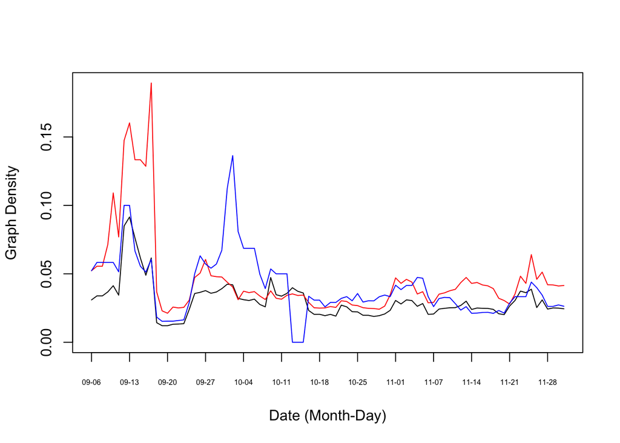

```r
startDate = as.POSIXct("2019-09-06");
endDate = as.POSIXct("2019-12-09");
all_dates = seq(startDate, endDate, 86400)
N=3
set.seed(0)

l = layout.fruchterman.reingold(ntwk_graph)
V(ntwk_graph)$label <- 1:532

fd <- c()
rd <- c()
dd <- c()
for(j in seq(from=8, to=length(all_dates), by=1)){
  dens <- mention_graph_density(j)
  fd <- c(fd,dens[1])
  rd <- c(rd,dens[2])
  dd <- c(dd,dens[3])
}

xind = c()
xtick = c()
for(i in seq(from=1, to = length(fd),by=7)){
  xind = c(xind,i)
  xtick = c(xtick,substr(all_dates[i],6,10))
}

rd <- ifelse(is.nan(rd),0,rd)
fd <- ifelse(is.nan(fd),0,fd)
dd <- ifelse(is.nan(dd),0,dd)

y = fd
x = 1:length(y)
plot(x,y,type='l',col='black',ylim=c(0, max(rd)),xaxt='n',xlab='Date (Month-Day)',ylab='Graph Density')
axis(side=1, at=xind,labels = xtick,cex.axis=.5)
lines(x,rd,type='l',col='red')
lines(x,dd,type='l',col='blue')
```

Make follow dataframe and subsequent network F

```r
load("~/Documents/R/Networks/sen_friends.RData")
load("~/Documents/R/Networks/rep_friends.RData")
legs <- read_csv("legislators-current.csv")
legs <- legs %>% filter(type=='sen'|type=='rep') %>% dplyr::select(twitter,party,govtrack_id,type)
legs <- na.omit(legs)
sens <- legs %>%filter(type == 'sen') %>% dplyr::select(twitter,party,govtrack_id)
reps <- legs %>% filter(type=='rep') %>% dplyr::select(twitter,party,govtrack_id)

senrep <- rbind(sens,reps)
senrep_friends <-rbind(sen_friends,rep_friends)
senrep_friends$followed<-tolower(senrep_friends$followed)
senrep_friends$follower<-tolower(senrep_friends$follower)
senrep$twitter <- tolower(senrep$twitter)
senrep_friends
```

```
## # A tibble: 55,688 x 2
##    follower        followed
##    <chr>           <chr>
##  1 sensherrodbrown repagonzalez
##  2 sensherrodbrown repbalderson
##  3 sensherrodbrown warrendavidson
##  4 sensherrodbrown senbillcassidy
##  5 sensherrodbrown senrickscott
##  6 sensherrodbrown senatorbraun
##  7 sensherrodbrown senhawleypress
##  8 sensherrodbrown senmcsallyaz
##  9 sensherrodbrown marshablackburn
## 10 sensherrodbrown senkevincramer
## # ... with 55,678 more rows
```

```r
senrep_friends2<-senrep_friends
senrep_friends2<-senrep_friends[senrep_friends$follower!='timkaine',]
senrep_friends2<-senrep_friends2[senrep_friends2$followed!='timkaine',]

follow_ntwk <- graph_from_data_frame(senrep_friends2, directed=TRUE,vertices=legislators)
follow_ntwk<-delete.vertices(follow_ntwk, degree(follow_ntwk)==0)
follow_ntwk
```

```
## IGRAPH f9459ad DN-B 529 55486 --
## + attr: name (v/c), party (v/c), govtrack_id (v/n), type (v/c),
## | terms (v/n), followed_by (v/n), follows (v/n), gender (v/c),
## | numtweets (v/n), dates (v/c)
## + edges from f9459ad (vertex names):
##  [1] sensherrodbrown->repagonzalez    sensherrodbrown->repbalderson
##  [3] sensherrodbrown->warrendavidson  sensherrodbrown->senbillcassidy
##  [5] sensherrodbrown->senrickscott    sensherrodbrown->senatorbraun
##  [7] sensherrodbrown->senhawleypress  sensherrodbrown->senmcsallyaz
##  [9] sensherrodbrown->marshablackburn sensherrodbrown->senkevincramer
## [11] sensherrodbrown->senatorromney   sensherrodbrown->senatorsinema
## + ... omitted several edges
```

Make function to restrict follow network with time window (see paper), return legislators with highest in-degree

```r
set.seed(0)
l_follow = layout.fruchterman.reingold(follow_ntwk)
V(follow_ntwk)[V(follow_ntwk)$party=='Democrat']$color<- "dodgerblue"
V(follow_ntwk)[V(follow_ntwk)$party=='Republican']$color<- "red"
V(follow_ntwk)$frame.color<-NA

N=3

timed_graph_follows <- function(j,plot=FALSE) {

upperdate = all_dates[j]
lower_week = all_dates[j-7]
lower_day = all_dates[j-1]

#tweets from the past week
week_tweets <- tweet_count[(tweet_count$created_at<=upperdate & tweet_count$created_at>lower_week),]
#all members who tweeted about impeachment in the past week
week_filter <- (V(follow_ntwk)$name %in% week_tweets$twitter)
#tweets from the past day
day_tweets <- tweet_count[(tweet_count$created_at<=upperdate & tweet_count$created_at>lower_day),]

#graph of legislators who tweeted about it in the past week
g <- induced_subgraph(follow_ntwk,V(follow_ntwk)[week_filter])

#members who tweeted about impeachment in the past day
day_filter <- (V(g)$name %in% day_tweets$twitter)
#delete any edges not from legislators who tweeted in the past day
g<- delete_edges(g,E(g)[!from(V(g)[day_filter])])

#get the same layout
l2 <- l_follow[week_filter,]

node_degree <- degree(g,mode='in')
V(g)$label<-NA

V(g)$size<-10
V(g)$size<-(strength(g,mode='in'))

title <- as.character(all_dates[j])

if(plot==TRUE){
plot(g, layout=l2,edge.arrow.size=0.01,asp=0,rescale=F,xlim = c(min(l_follow[,1]), max(l_follow[,1])),
ylim = c(min(l_follow[,2]), max(l_follow[,2])),main=title)
}
return(names(sort(node_degree,decreasing=TRUE)[1:N]))

}
```

Output users with highest in-degree over time

```r
high_names <-c()
for(i in 8:length(all_dates)){
val <- timed_graph_follows(i,FALSE)
high_names <- c(high_names,val)
}

top_follows <- sort(table(high_names),decreasing=TRUE)[1:10]
top_follows
```

```
## high_names
##       gopleader    stevescalise   speakerpelosi      jim_jordan
##              57              46              19              17
##   repkevinbrady     leaderhoyer      johncornyn  repmarkmeadows
##              16              14              13               7
## marshablackburn   repjeffduncan
##               6               6
```

Collect highest impact users

```r
top_users <- c(top_evs,top_follows)
top_users <- unique(names(top_users))
top_users
```

```
##  [1] "gopleader"       "stevescalise"    "repadamschiff"
##  [4] "speakerpelosi"   "repdougcollins"  "repmarkmeadows"
##  [7] "jimpressoffice"  "repfredkeller"   "repstevechabot"
## [10] "replizcheney"    "jim_jordan"      "repkevinbrady"
## [13] "leaderhoyer"     "johncornyn"      "marshablackburn"
## [16] "repjeffduncan"
```

Plot follow network among highest impact users

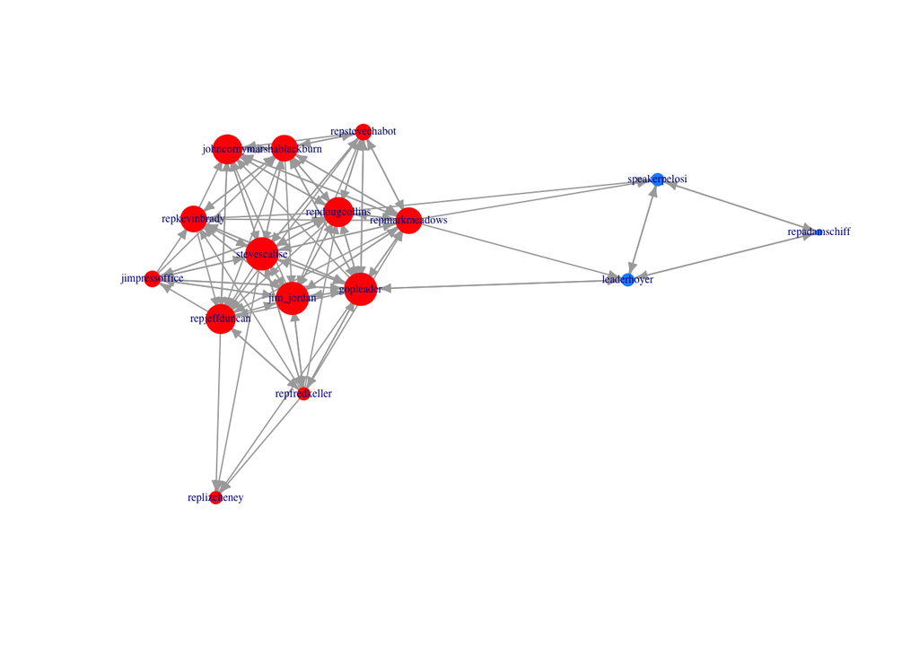

```r
set.seed(0)
follow_ntwk <- graph_from_data_frame(senrep_friends2, directed=TRUE,vertices=legislators)
follow_ntwk<-delete.vertices(follow_ntwk, degree(follow_ntwk)==0)
V(follow_ntwk)[V(follow_ntwk)$party=='Democrat']$color<- "dodgerblue"
V(follow_ntwk)[V(follow_ntwk)$party=='Republican']$color<- "red"
V(follow_ntwk)$frame.color<-NA
g <- induced_subgraph(follow_ntwk,V(follow_ntwk)[V(follow_ntwk)$name %in% top_users])

V(g)$label<-V(g)$name
V(g)$label.cex = .5

V(g)$size<-(strength(g,mode='in'))
plot(g, layout=layout.fruchterman.reingold(g),edge.arrow.size=.5,asp=0)
```

Plot interaction network among highest impact users

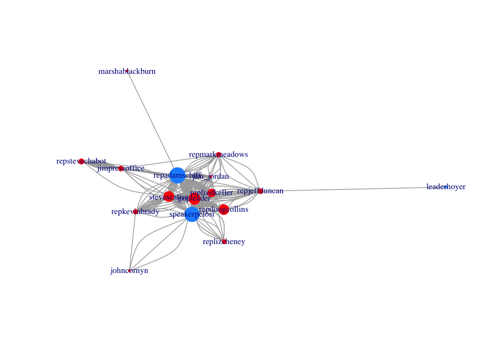

```r
g <- induced_subgraph(ntwk_graph,V(ntwk_graph)[V(ntwk_graph)$name %in% top_users])
V(g)$label<-V(g)$name
V(g)$label.cex = .7
V(g)$size<-sqrt(strength(g,mode='in'))


plot(g, layout=layout.fruchterman.reingold(g),edge.arrow.size=.1,asp=0)
```

Collect tweets from top users

```r
top_user_tweets <- impeach_tweets_full
top_user_tweets$screen_name <- tolower(top_user_tweets$screen_name)
top_user_tweets <- top_user_tweets %>% filter(screen_name %in% top_users)
top_user_tweets
```

```
## # A tibble: 1,595 x 90
##    user_id status_id created_at          screen_name text  source
##    <chr>   <chr>     <dttm>              <chr>       <chr> <chr>
##  1 132181… 12040470… 2019-12-09 14:36:04 johncornyn  "\"F… Twitt…
##  2 132181… 12033357… 2019-12-07 15:29:40 johncornyn  Than… Twitt…
##  3 132181… 12029863… 2019-12-06 16:21:20 johncornyn  Pelo… Twitt…
##  4 132181… 12029348… 2019-12-06 12:56:39 johncornyn  I do… Twitt…
##  5 132181… 12029348… 2019-12-06 12:56:39 johncornyn  "\"J… Twitt…
##  6 132181… 12026620… 2019-12-05 18:52:22 johncornyn  "Spe… Twitt…
##  7 132181… 12026561… 2019-12-05 18:29:03 johncornyn  Unfo… Twitt…
##  8 132181… 12026045… 2019-12-05 15:04:00 johncornyn  Sadl… Twitt…
##  9 132181… 12025546… 2019-12-05 11:45:52 johncornyn  "Pin… Twitt…
## 10 132181… 12025478… 2019-12-05 11:18:41 johncornyn  From… Twitt…
## # ... with 1,585 more rows, and 84 more variables:
## #   display_text_width <dbl>, reply_to_status_id <chr>,
## #   reply_to_user_id <chr>, reply_to_screen_name <chr>, is_quote <lgl>,
## #   is_retweet <lgl>, favorite_count <int>, retweet_count <int>,
## #   quote_count <int>, reply_count <int>, hashtags <list>, symbols <list>,
## #   urls_url <list>, urls_t.co <list>, urls_expanded_url <list>,
## #   media_url <list>, media_t.co <list>, media_expanded_url <list>,
## #   media_type <list>, ext_media_url <list>, ext_media_t.co <list>,
## #   ext_media_expanded_url <list>, ext_media_type <chr>,
## #   mentions_user_id <list>, mentions_screen_name <list>, lang <chr>,
## #   quoted_status_id <chr>, quoted_text <chr>, quoted_created_at <dttm>,
## #   quoted_source <chr>, quoted_favorite_count <int>,
## #   quoted_retweet_count <int>, quoted_user_id <chr>,
## #   quoted_screen_name <chr>, quoted_name <chr>,
## #   quoted_followers_count <int>, quoted_friends_count <int>,
## #   quoted_statuses_count <int>, quoted_location <chr>,
## #   quoted_description <chr>, quoted_verified <lgl>,
## #   retweet_status_id <chr>, retweet_text <chr>,
## #   retweet_created_at <dttm>, retweet_source <chr>,
## #   retweet_favorite_count <int>, retweet_retweet_count <int>,
## #   retweet_user_id <chr>, retweet_screen_name <chr>, retweet_name <chr>,
## #   retweet_followers_count <int>, retweet_friends_count <int>,
## #   retweet_statuses_count <int>, retweet_location <chr>,
## #   retweet_description <chr>, retweet_verified <lgl>, place_url <chr>,
## #   place_name <chr>, place_full_name <chr>, place_type <chr>,
## #   country <chr>, country_code <chr>, geo_coords <list>,
## #   coords_coords <list>, bbox_coords <list>, status_url <chr>,
## #   name <chr>, location <chr>, description <chr>, url <chr>,
## #   protected <lgl>, followers_count <int>, friends_count <int>,
## #   listed_count <int>, statuses_count <int>, favourites_count <int>,
## #   account_created_at <dttm>, verified <lgl>, profile_url <chr>,
## #   profile_expanded_url <chr>, account_lang <lgl>,
## #   profile_banner_url <chr>, profile_background_url <chr>,
## #   profile_image_url <chr>
```

Create df of top users’ twitter activity over time

```r
top_user_df <- data.frame(top_users)
names(top_user_df)<-"screen_name"
top_user_df$screen_name <- as.character(top_user_df$screen_name)

for(j in 2:length(all_dates)){
upperdate = all_dates[j]
lowerdate = all_dates[j-1]

#tweets from the past week
week_tweets <- top_user_tweets[top_user_tweets$created_at<upperdate & top_user_tweets$created_at>lowerdate,]

week_df <- week_tweets %>% group_by(screen_name) %>% count() %>% select(screen_name,n)
names(week_df) <- c("screen_name",as.character(upperdate))
top_user_df <- top_user_df %>% full_join(week_df,by='screen_name')

}
top_user_df[is.na(top_user_df)] <- 0

twitter_party <- legislators %>% select(twitter,party)
names(twitter_party)<-c("screen_name","party")
top_user_df <- top_user_df %>% left_join(twitter_party,by='screen_name')
top_user_df
```

```
##        screen_name 2019-09-07 2019-09-08 2019-09-09 2019-09-10 2019-09-11
## 1        gopleader          0          0          0          0          0
## 2     stevescalise          0          0          0          0          1
## 3    repadamschiff          0          0          0          0          0
## 4    speakerpelosi          0          0          0          0          0
## 5   repdougcollins          0          0          0          2          0
## 6   repmarkmeadows          0          0          0          2          3
## 7   jimpressoffice          0          0          0          0          0
## 8    repfredkeller          0          0          0          0          0
## 9   repstevechabot          0          0          0          0          0
## 10    replizcheney          0          0          0          0          1
## 11      jim_jordan          0          0          0          3          2
## 12   repkevinbrady          0          0          0          1          0
## 13     leaderhoyer          0          0          0          0          0
## 14      johncornyn          0          0          0          0          0
```

[output cut: 359 more lines]

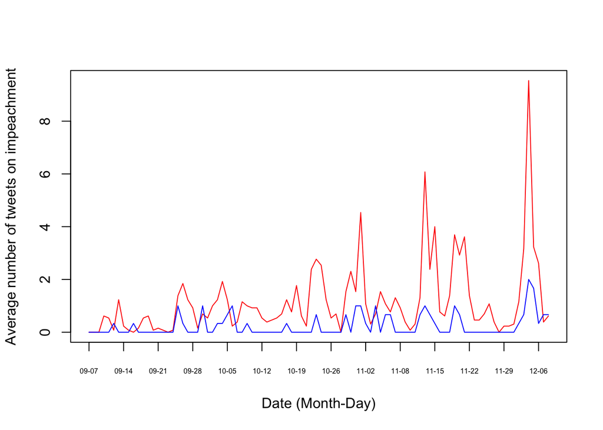

```r
xind = c()
xtick = c()
for(i in seq(from=1, to = length(top_user_df),by=7)){
  xind = c(xind,i)
  xtick = c(xtick,substr(all_dates[i+1],6,10))
}

rep_df <- top_user_df %>% filter(party=="Republican")
dem_df <- top_user_df %>% filter(party=="Democrat")
rep_mean = c()
dem_mean = c()
for(i in 2:95){
  rep_mean <- c(rep_mean,mean(rep_df[,i]))
  dem_mean <- c(dem_mean,mean(dem_df[,i]))
}
plot(1:length(rep_mean),rep_mean,type='l',col='red',xaxt = 'n',xlab="Date (Month-Day)", ylab="Average number of tweets on impeachment")
axis(side=1,at=xind,labels=xtick,cex.axis=.5)
lines(1:length(rep_mean),dem_mean,type='l',col='blue')
```

Plot interaction graph for a topic, colored for party and for cluster

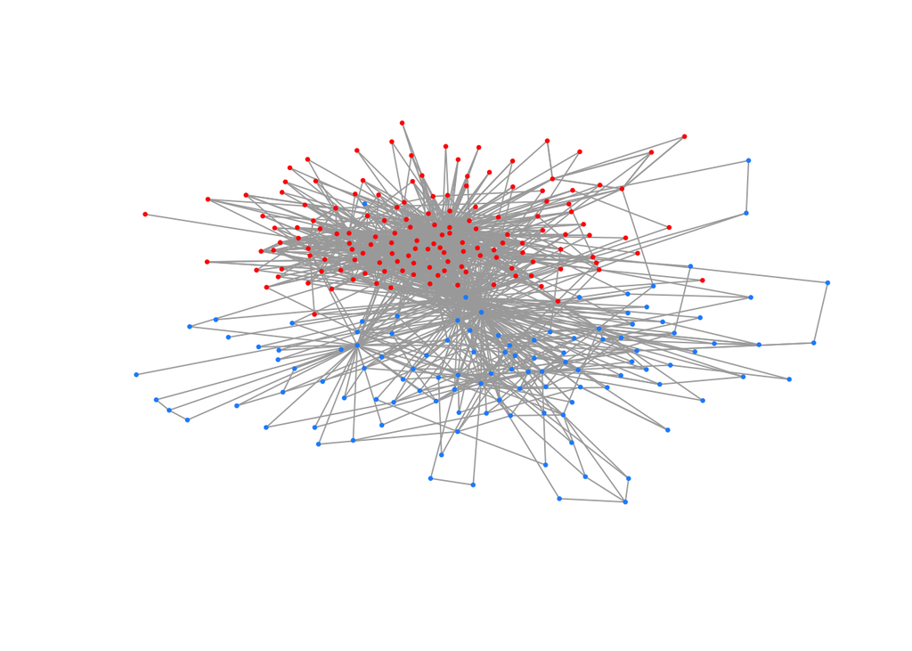

```r
tg <-ntwk_graph

E(tg)$weights<-1
g <- delete_edge_attr(tg,"created_at")
g <- delete_edge_attr(g,"text")
g <- delete_edge_attr(g,"status_id")
g <- delete_edge_attr(g,"interaction_type")
g<- simplify(g, edge.attr.comb="sum")
g<- delete.vertices(g, degree(g)<=1)
g<- decompose.graph(g,max.comps=1)[[1]]
comms <- cluster_fast_greedy(as.undirected(g))
V(g)$group <- cutat(comms,2)
V(g)$label<- NA
V(g)$size<- 1
V(g)[length(V(g))]$party = "Republican"
V(g)[party == 'Republican']$color <- "red"
V(g)[party == 'Republican']$frame.color <- "red"
V(g)[party == 'Democrat']$color <- "dodgerblue"
V(g)[party == 'Democrat']$frame.color <- "dodgerblue"
l = layout.fruchterman.reingold(g)
plot(g,layout = l,edge.arrow.size=0.01,asp=0)
```

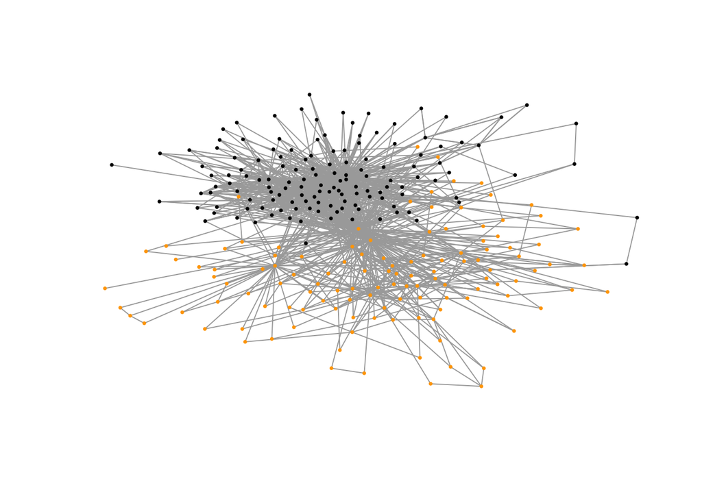

```r
comms <- cluster_fast_greedy(as.undirected(g))
V(g)$group <- cutat(comms,2)
V(g)[group == 1]$color <- "black"
V(g)[group == 2]$color <- "orange"
V(g)$frame.color<-"black"
V(g)[group == 2]$frame.color <- "orange"
plot(g,layout = l,edge.arrow.size=0.01,asp=0)
```

Define the partisan number for a chosen word

```r
partisan_number <- function(chosen_word){

  impeach <- str_detect(tweets$text, regex(chosen_word,ignore_case=TRUE))
  impeach_tweets <- tweets %>% filter(impeach)

  df <- impeach_tweets
  # all mentions, as string
  mention_list <- vector("list", nrow(impeach_tweets))
  for(i in 1:nrow(impeach_tweets)){
    mentions <- impeach_tweets$mentions_screen_name[i][[1]]
    mentions <- paste(mentions,collapse=',')[[1]]
    mention_list[[i]]<-ifelse(mentions=="NA",NA,mentions)
  }
  df$mentions <- mention_list
  df <- transform(df, mentions = as.character(mentions))
  df <- df %>% dplyr::select(screen_name,reply_to_screen_name,quoted_screen_name,retweet_screen_name,mentions,text,status_id,created_at)
  # all interactions as string
  df <- unite(df,interaction_name,2:5,sep=",",remove=FALSE)
  # all interactions, separate rows, edges only when interacting with other legislators
  df <- separate_rows(df,interaction_name) %>% filter(tolower(interaction_name) %in% legislators$twitter)
  df <- unique(df)
  # remove self edges
  df <- filter(df,interaction_name!=screen_name)

  # tweet dates, interaction types
  df$created_at<-as.Date(df$created_at)
  df$interaction_type <- ifelse(is.na(df$reply_to_screen_name),ifelse(is.na(df$quoted_screen_name),ifelse(is.na(df$retweet_screen_name),'mention','retweet'),'quote'),'reply')

  df$screen_name<-tolower(df$screen_name)
  df$interaction_name<-tolower(df$interaction_name)
  df <- df %>% dplyr::select(screen_name,interaction_name,text,status_id,interaction_type,created_at)
  #df
  df$created_at<-as.character(df$created_at)

  ntwk_graph <- graph_from_data_frame(df, directed = TRUE, vertices=legislators)

  tg <-ntwk_graph
  E(tg)$weights<-1
  g <- delete_edge_attr(tg,"created_at")
  g <- delete_edge_attr(g,"text")
  g <- delete_edge_attr(g,"status_id")
  g <- delete_edge_attr(g,"interaction_type")
  g<- simplify(g, edge.attr.comb="sum")
  g<- delete.vertices(g, degree(g)<=1)
  g<- decompose.graph(g,max.comps=1)[[1]]
  comms <- cluster_fast_greedy(as.undirected(g))
  V(g)$group <- cutat(comms,2)

  group_df <- data.frame(V(g)$name,V(g)$group)
  names(group_df)<-c("twitter","group")
  group_df$twitter <- as.character(group_df$twitter)
  leg_group <- legislators %>% inner_join(group_df,by='twitter')


  df1 <- leg_group %>% select(party,group) %>% filter(group==1) %>% group_by(party) %>% count() %>% arrange(desc(n))
  df2 <- leg_group %>% select(party,group) %>% filter(group==2) %>% group_by(party) %>% count() %>% arrange(desc(n))
  return((max(df1$n)/sum(df1$n)+max(df2$n)/sum(df2$n))/2)
}
```